# Домашнее задание №1

Методы кодирования и модуляция сигналов

Саенко Анна Андреевна

1132246833@rudn.ru

Российский университет дружбы народов

2026-09-06

# Цели и задачи работы

## Цель лабораторной работы

Изучение методов кодирования и модуляции сигналов с помощью Octave, определение спектра и параметров сигналов, а также исследование свойства самосинхронизации кодированных сигналов.

## Задачи лабораторной работы

- построить графики гармонических функций;
- выполнить разложение меандра в частичный ряд Фурье;
- определить спектры отдельных сигналов и их суммы;
- исследовать амплитудную модуляцию;
- построить сигналы для разных способов кодирования;
- проверить свойство самосинхронизации;
- получить спектры кодированных сигналов.

# Процесс выполнения лабораторной работы

## Построение графика функции синуса

В Octave создан сценарий `plot_sin.m`, в котором построен график функции  
$y_1 = \sin x + \frac{1}{3}\sin 3x + \frac{1}{5}\sin 5x$  
на интервале от -10 до 10.

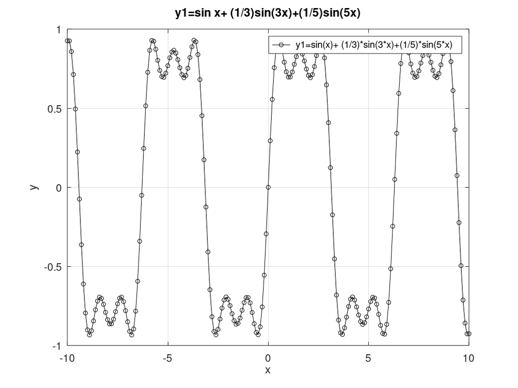

График функции синуса

## Построение графиков синуса и косинуса

Создан сценарий `plot_sin_cos.m`, в котором в одной системе координат построены графики функций `y1` и `y2`.

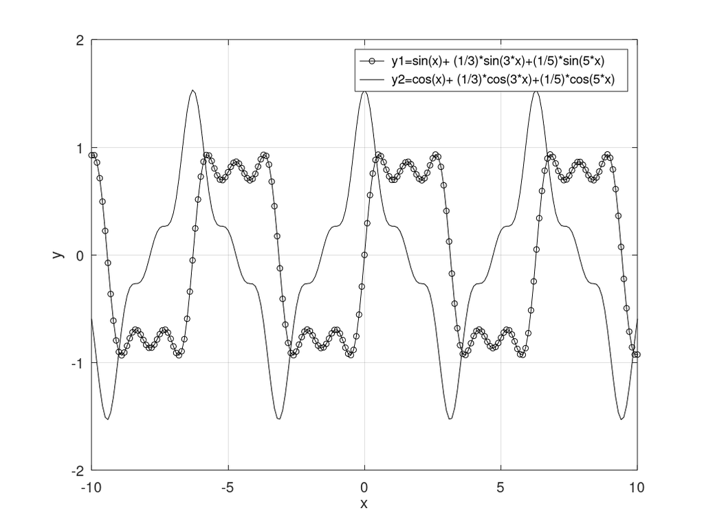

Графики функций y1 и y2

## Разложение меандра через косинусы

Создан сценарий `meandr.m`. С помощью частичного ряда Фурье построены графики меандра при различном количестве нечётных гармоник.

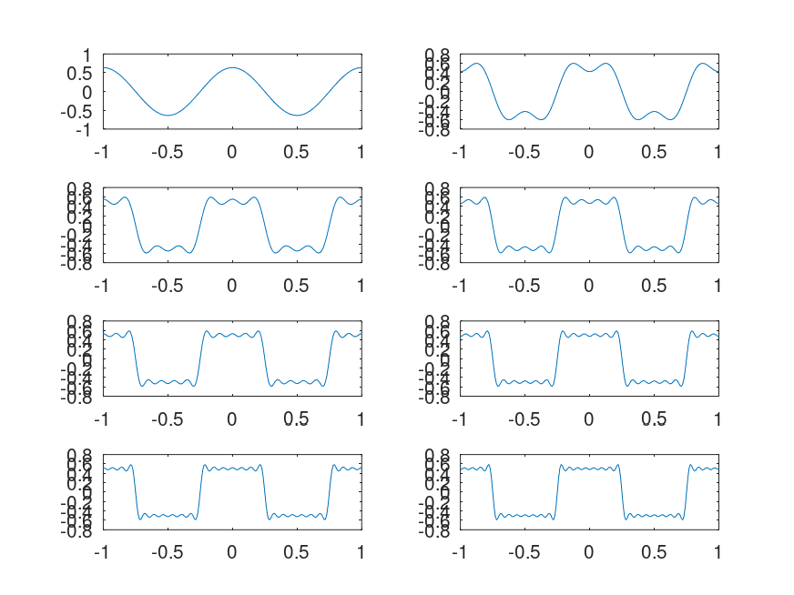

Разложение меандра через косинусоидальные гармоники

## Разложение меандра через синусы

Создан сценарий `meandr2.m`, в котором меандр реализован через синусоидальные нечётные гармоники.

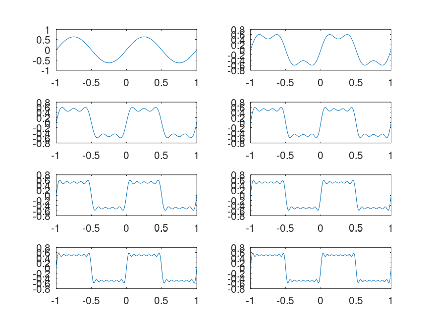

Разложение меандра через синусоидальные гармоники

## Определение спектров двух сигналов

В каталоге `spectre1` создан сценарий `spectre.m`. Построены два синусоидальных сигнала с частотами 10 Гц и 40 Гц.

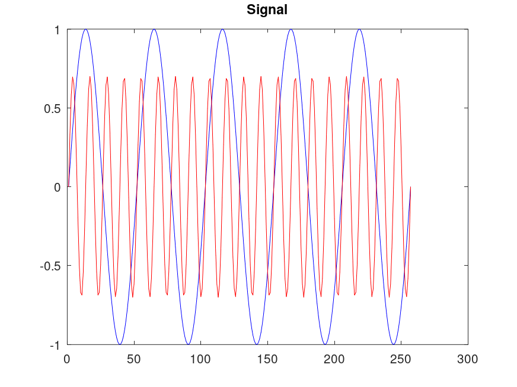

Два синусоидальных сигнала

## Исходный спектр сигналов

С помощью функции `fft` получены спектры двух синусоидальных сигналов.

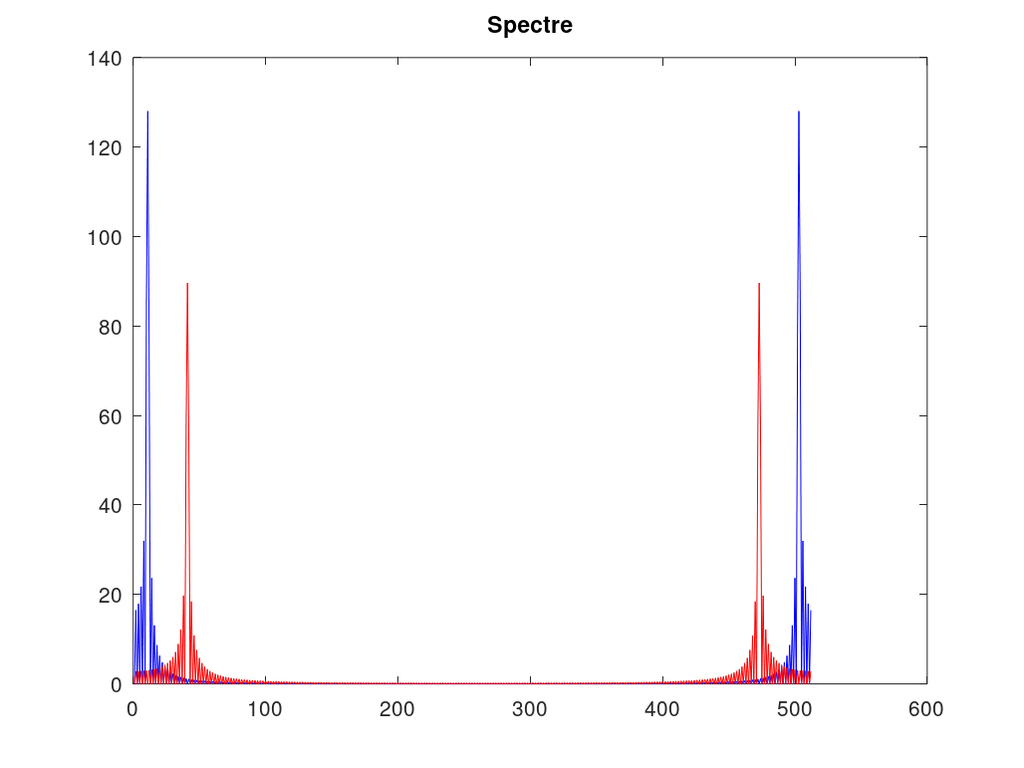

Исходный спектр сигналов

## Исправленный спектр сигналов

Выполнена нормировка спектров и удаление дублирующих отрицательных частот. На графике видны максимумы около 10 Гц и 40 Гц.

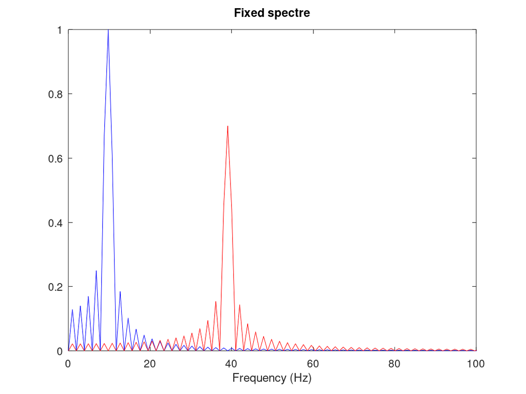

Исправленный спектр сигналов

## Суммарный сигнал

В сценарии `spectr_sum/spectre_sum.m` выполнено сложение двух синусоидальных сигналов.

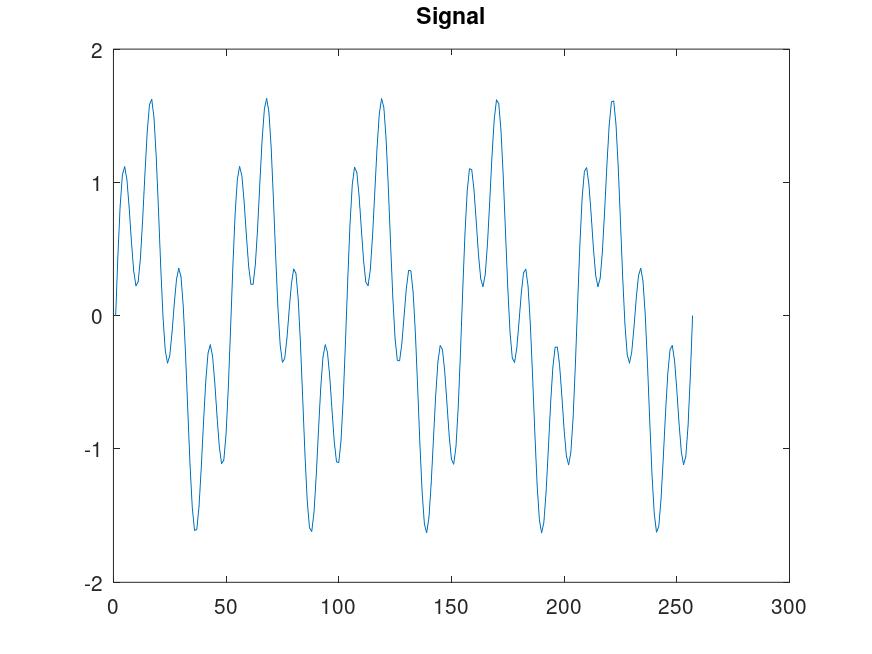

Суммарный сигнал

## Спектр суммарного сигнала

Получен спектр суммы сигналов. В нём сохраняются частотные составляющие исходных сигналов.

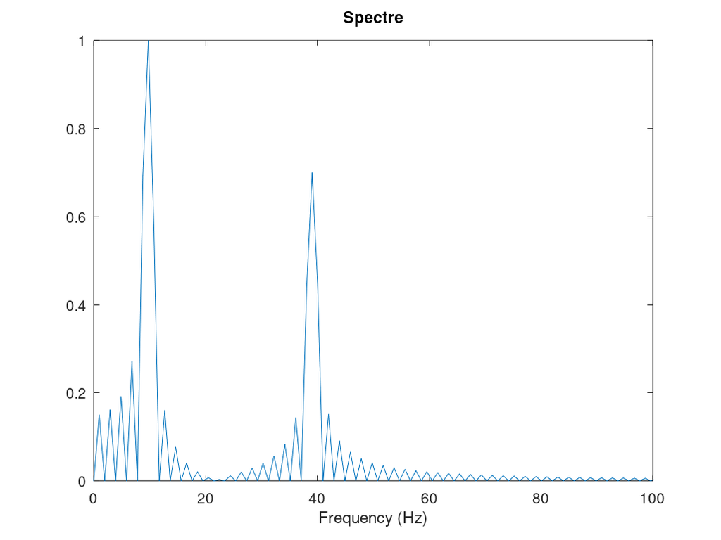

Спектр суммарного сигнала

## Амплитудная модуляция

В каталоге `modulation` создан сценарий `am.m`. Модулированный сигнал получен умножением информационного сигнала частотой 5 Гц на несущий сигнал частотой 50 Гц.

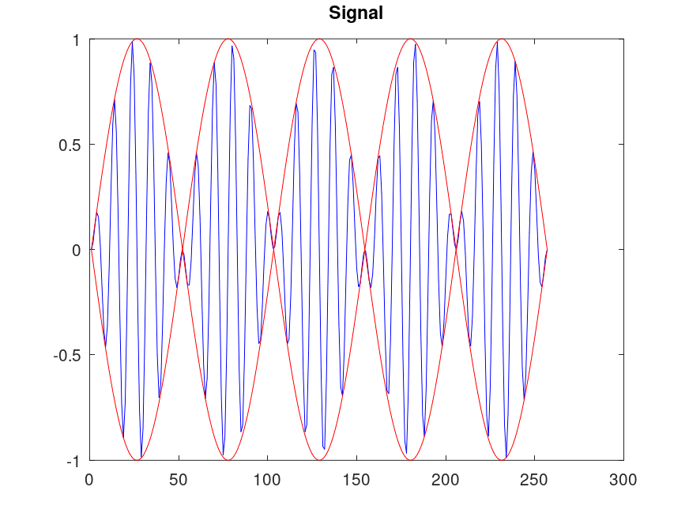

Сигнал и огибающая при амплитудной модуляции

## Спектр амплитудно-модулированного сигнала

Построен спектр модулированного сигнала. Основные составляющие расположены около частот 45 Гц и 55 Гц.

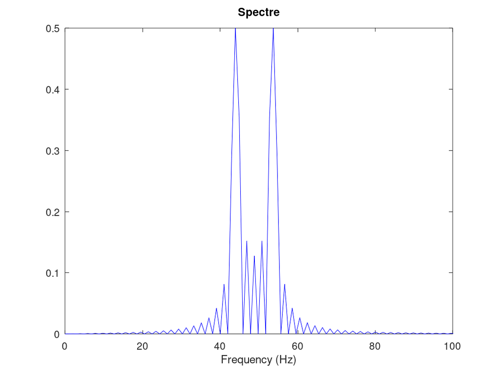

Спектр сигнала при амплитудной модуляции

# Кодирование сигнала

## Построение кодированных сигналов

В каталоге `coding` созданы файлы `main.m`, `maptowave.m`, `unipolar.m`, `ami.m`, `bipolarnrz.m`, `bipolarrz.m`, `manchester.m`, `diffmanc.m` и `calcspectre.m`.

Для исходной битовой последовательности построены сигналы различных способов кодирования.

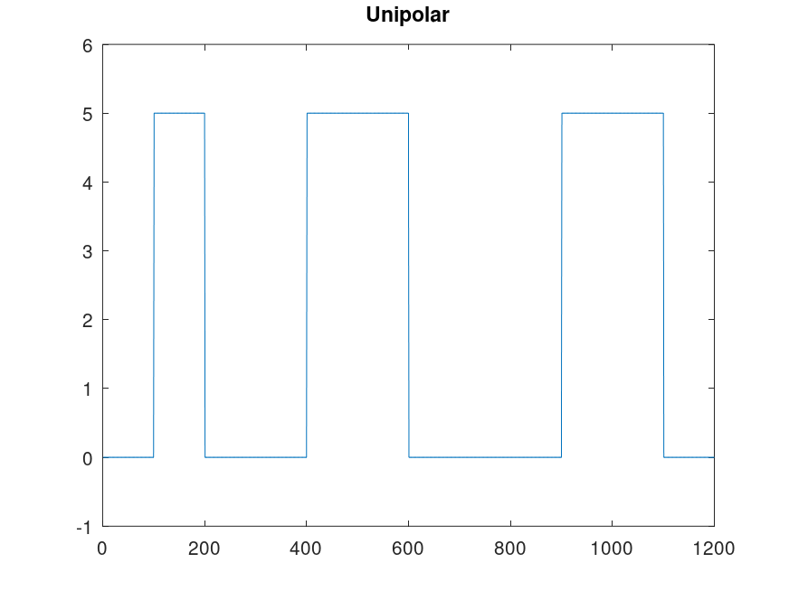

Кодированные сигналы

## Кодирование AMI

При кодировании AMI нулевые биты передаются нулевым уровнем, а единичные импульсы чередуют полярность.

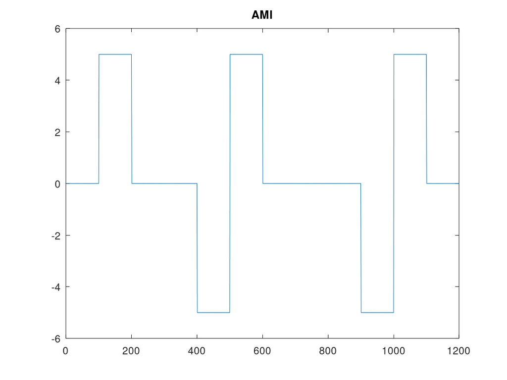

Кодирование AMI

## Биполярное кодирование NRZ

При кодировании NRZ логические значения представлены двумя противоположными уровнями сигнала.

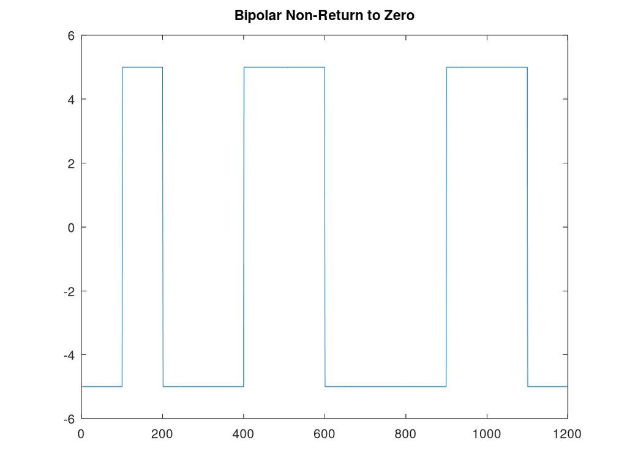

Биполярное кодирование NRZ

## Биполярное кодирование RZ

В коде RZ сигнал возвращается к нулевому уровню внутри каждого битового интервала.

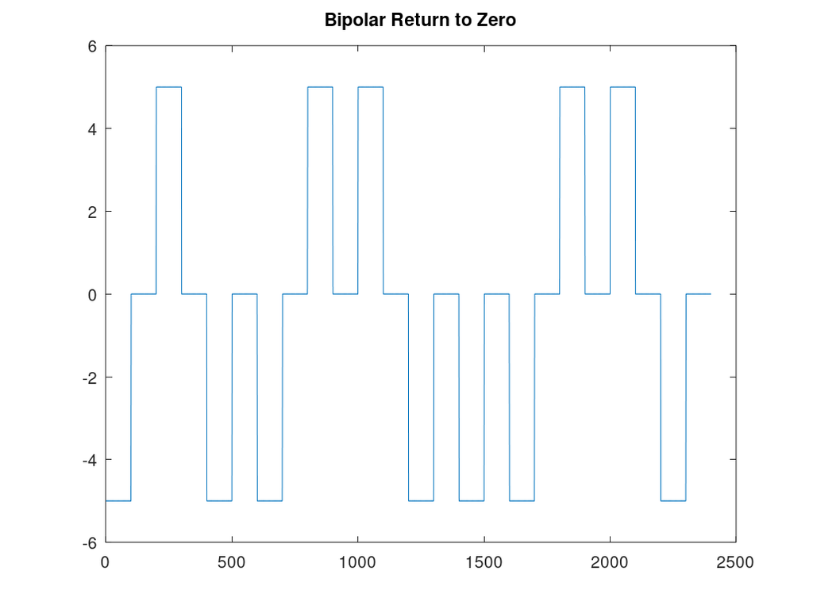

Биполярное кодирование RZ

## Манчестерское кодирование

При манчестерском кодировании в середине каждого битового интервала происходит обязательный переход уровня.

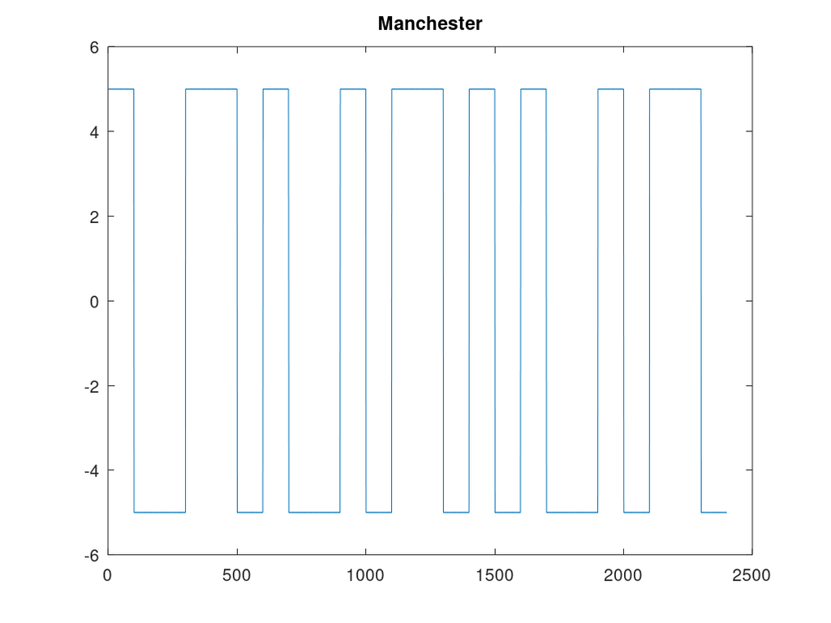

Манчестерское кодирование

## Дифференциальное манчестерское кодирование

В дифференциальном манчестерском коде информация определяется характером переходов сигнала.

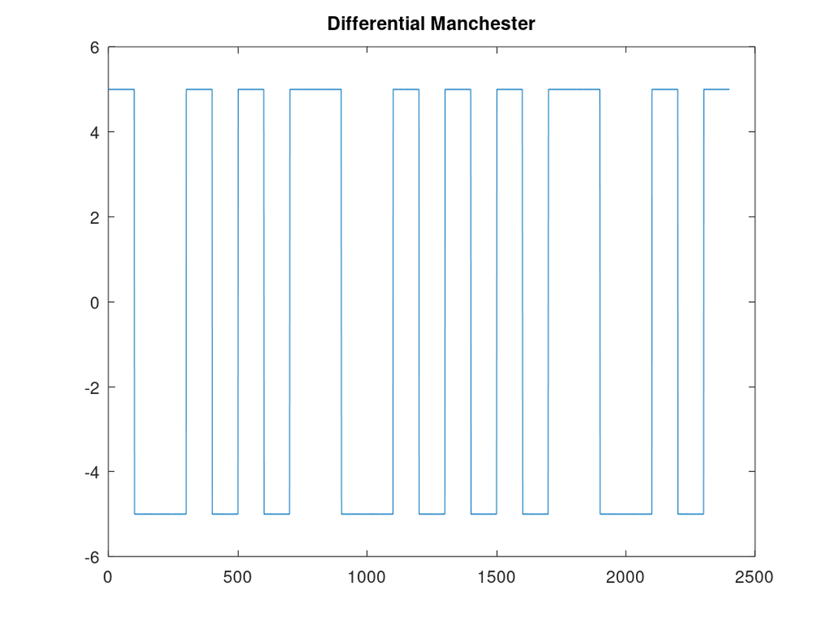

Дифференциальное манчестерское кодирование

# Самосинхронизация

## Проверка самосинхронизации кодов

Для проверки использована последовательность `data_sync`, содержащая длинные группы одинаковых битов.

Униполярный код и NRZ не обеспечивают самосинхронизацию, так как при длинных последовательностях одинаковых битов отсутствуют переходы уровня.

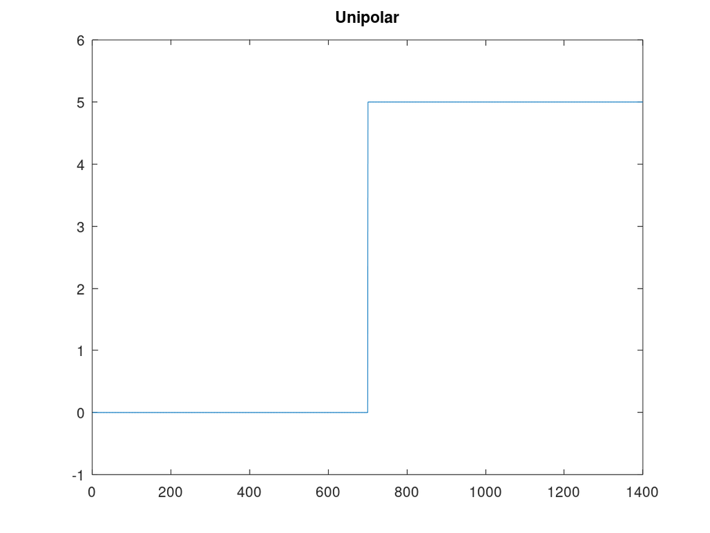

Проверка самосинхронизации униполярного кода

## Самосинхронизация AMI

AMI обеспечивает переходы при наличии единичных импульсов, но длинная последовательность нулей не содержит изменений уровня.

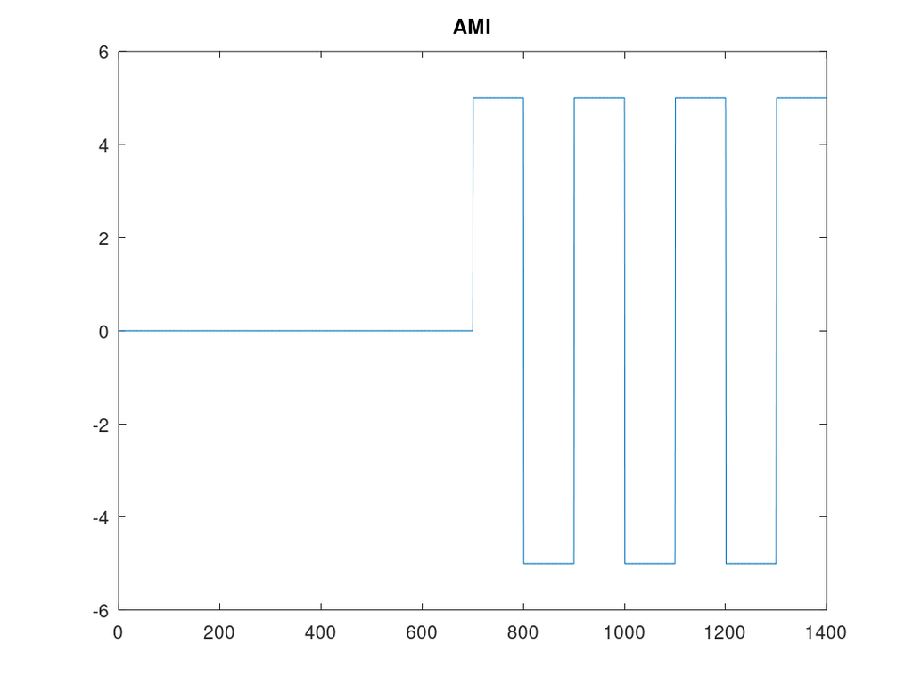

Проверка самосинхронизации AMI

## Самосинхронизирующиеся коды

RZ, манчестерский и дифференциальный манчестерский коды содержат регулярные переходы уровня, поэтому обладают свойством самосинхронизации.

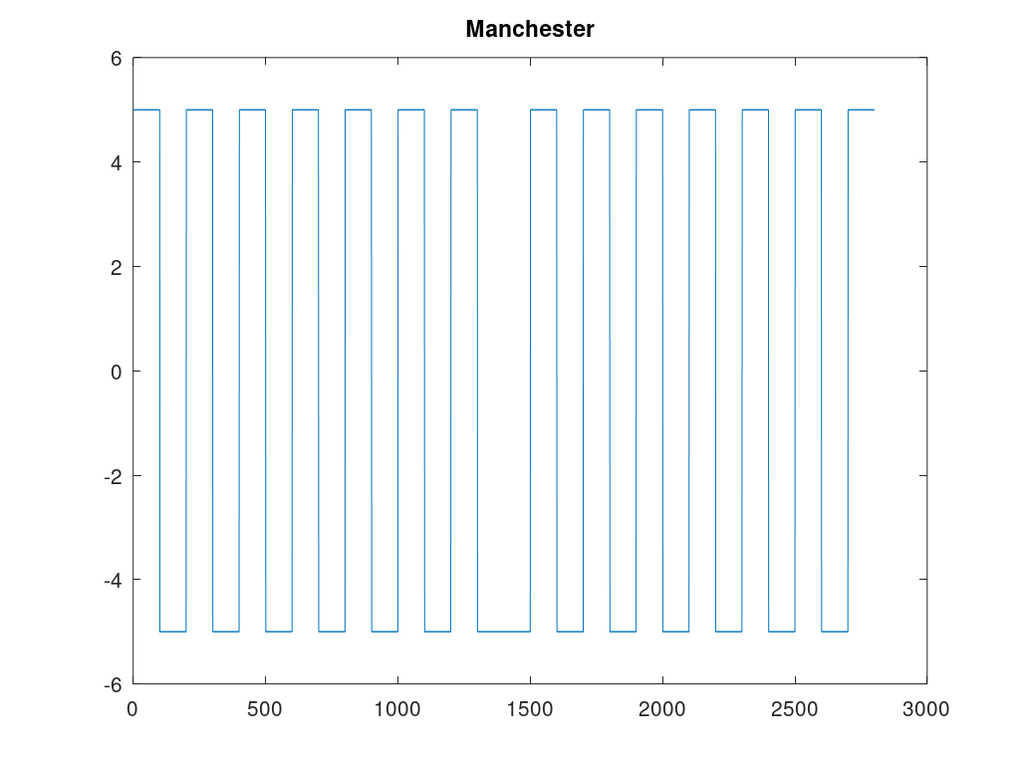

Проверка самосинхронизации манчестерского кода

# Спектры кодированных сигналов

## Спектр униполярного сигнала

Для построения спектров используется функция `calcspectre.m`, основанная на быстром преобразовании Фурье.

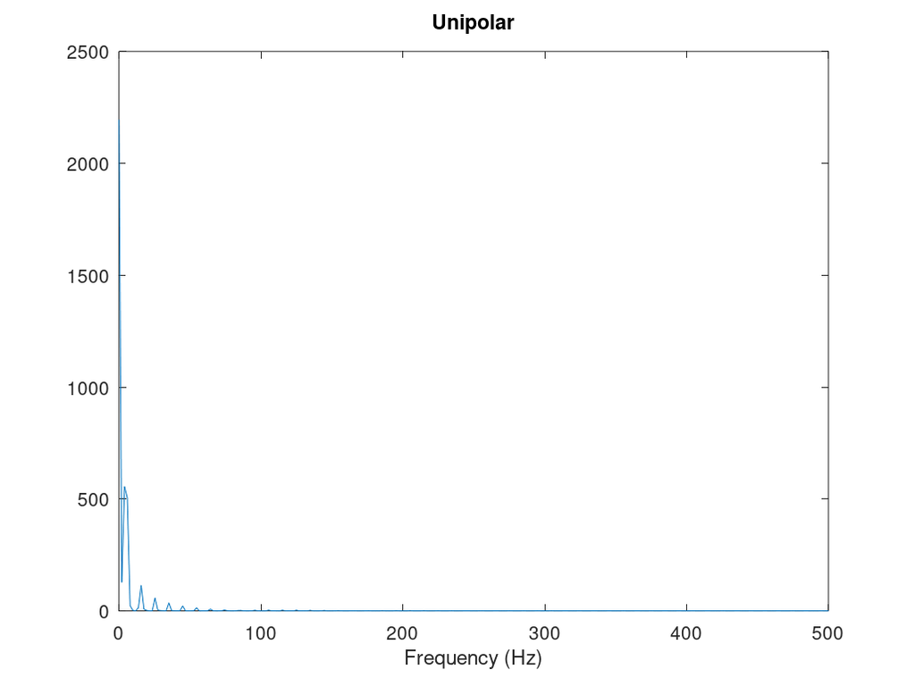

Спектр униполярного сигнала

## Спектр AMI

Построен спектр сигнала, полученного при кодировании AMI.

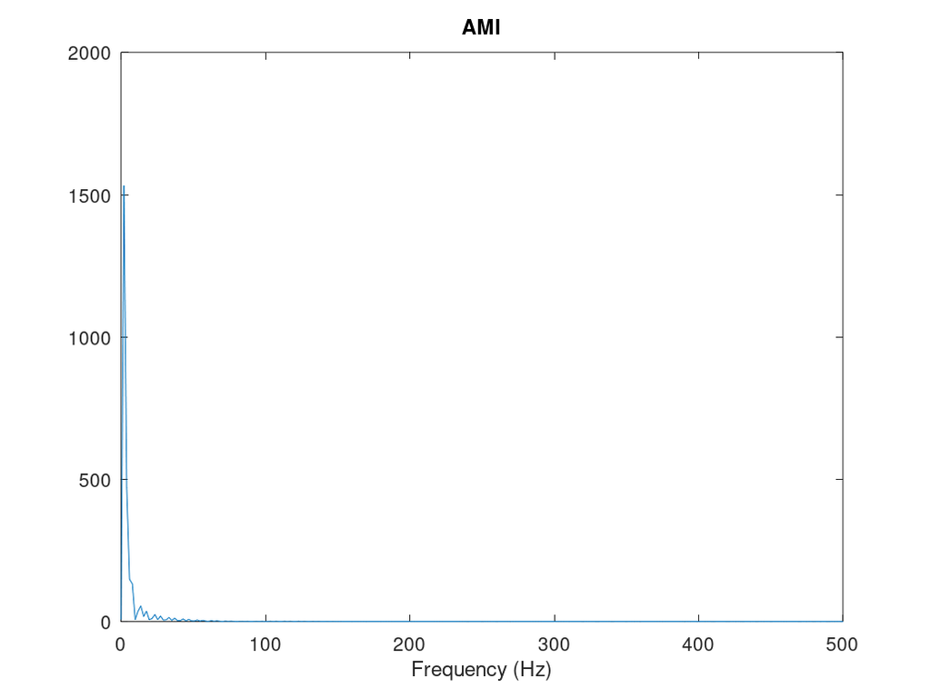

Спектр AMI

## Спектр NRZ

Построен спектр сигнала при биполярном кодировании NRZ.

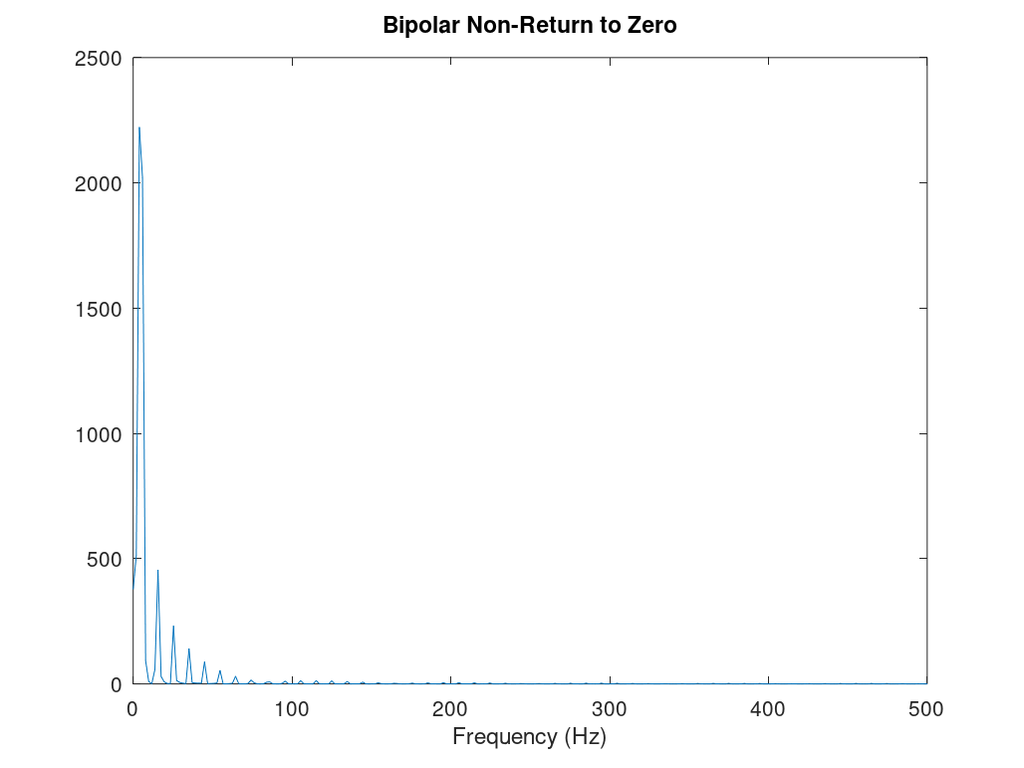

Спектр NRZ

## Спектр RZ

Построен спектр сигнала при биполярном кодировании RZ.

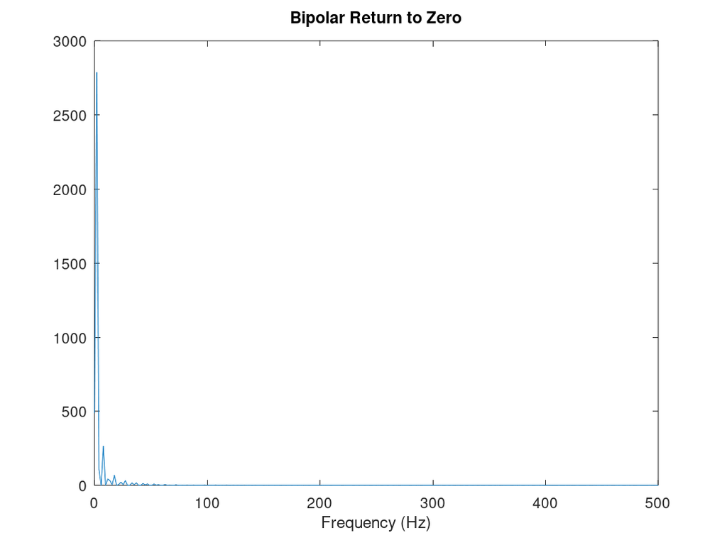

Спектр RZ

## Спектр манчестерского кода

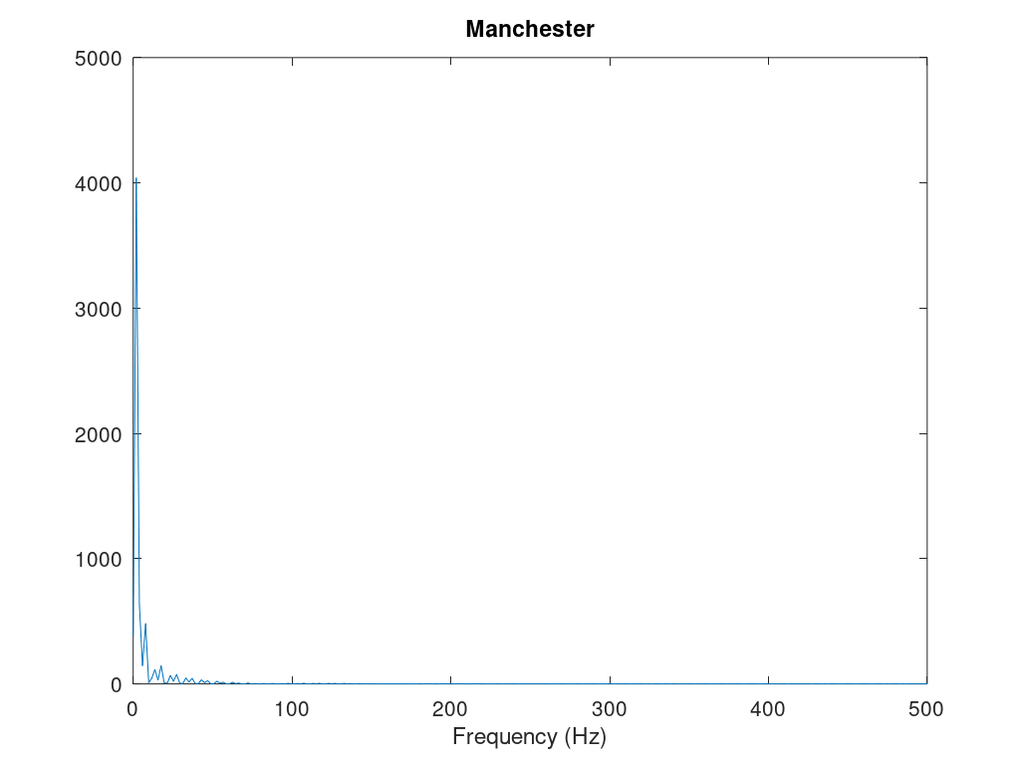

Спектр манчестерского кода

## Спектр дифференциального манчестерского кода

Построен спектр дифференциального манчестерского сигнала.

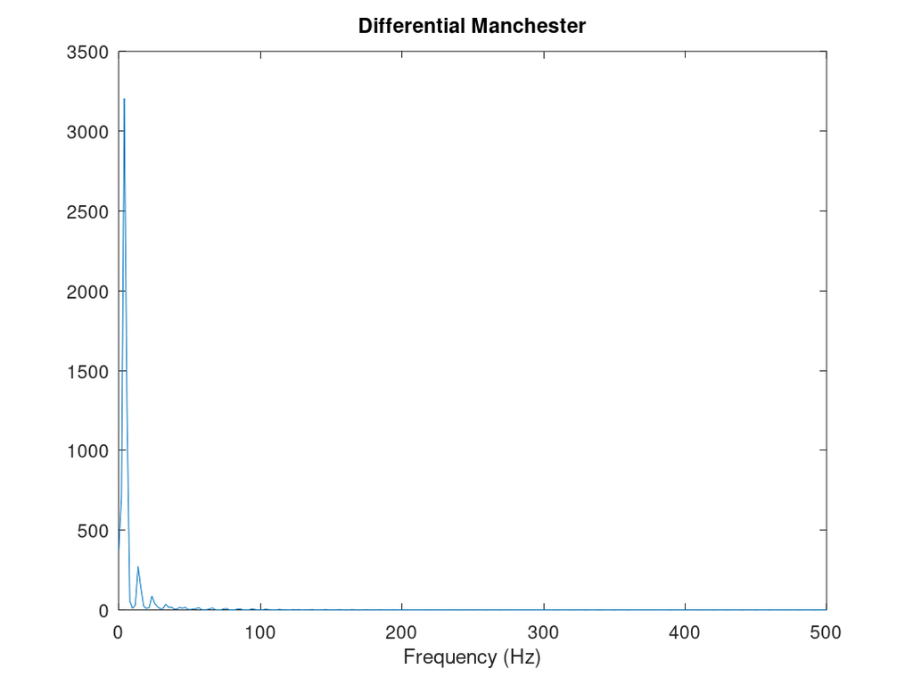

Спектр дифференциального манчестерского кода

# Результаты работы

## Полученные результаты

В ходе лабораторной работы были получены:

- графики гармонических функций;
- графики разложения меандра в частичный ряд Фурье;
- спектры отдельных сигналов;
- спектр суммы сигналов;
- сигнал и спектр при амплитудной модуляции;
- графики различных способов кодирования;
- результаты проверки самосинхронизации;
- спектры кодированных сигналов.

## Вывод

В ходе лабораторной работы были изучены методы кодирования и модуляции сигналов средствами Octave.

Было установлено, что увеличение числа нечётных гармоник улучшает приближение меандра. С помощью преобразования Фурье были определены спектры сигналов и подтверждено, что спектр суммы содержит составляющие исходных сигналов.

На примере амплитудной модуляции показано появление частотных составляющих, равных сумме и разности частот информационного и несущего сигналов.

Также были исследованы свойства самосинхронизации кодов. Униполярный код и NRZ не обеспечивают самосинхронизацию, AMI обеспечивает её только при наличии импульсов, а RZ, манчестерский и дифференциальный манчестерский коды обладают свойством самосинхронизации.